# Secrets of wine by Hernan Antolini

## Overview

> I am from Argentina. In the west region of my country, near the Andean mountains, red wine from France, has found a wonderfull place to growth. It seems that it is mostly related with the weather conditions (desert with differences in temperatures within the day and sunny) but, since red wine in Argentina is as famous as futbol or tango, everyone has an opinion on it. So, this dataset, i hope, will be a great opportunity to search for an educated opinion, mostly a scientific opinion, on this wonderfull beverage. As romans used to say : “In vino veritas” " ! (In wine, the truth)

## Univariate

```
##        X          fixed.acidity   volatile.acidity  citric.acid
##  Min.   :   1.0   Min.   : 4.60   Min.   :0.1200   Min.   :0.000
##  1st Qu.: 400.5   1st Qu.: 7.10   1st Qu.:0.3900   1st Qu.:0.090
##  Median : 800.0   Median : 7.90   Median :0.5200   Median :0.260
##  Mean   : 800.0   Mean   : 8.32   Mean   :0.5278   Mean   :0.271
##  3rd Qu.:1199.5   3rd Qu.: 9.20   3rd Qu.:0.6400   3rd Qu.:0.420
##  Max.   :1599.0   Max.   :15.90   Max.   :1.5800   Max.   :1.000
##  residual.sugar     chlorides       free.sulfur.dioxide
##  Min.   : 0.900   Min.   :0.01200   Min.   : 1.00
##  1st Qu.: 1.900   1st Qu.:0.07000   1st Qu.: 7.00
##  Median : 2.200   Median :0.07900   Median :14.00
##  Mean   : 2.539   Mean   :0.08747   Mean   :15.87
##  3rd Qu.: 2.600   3rd Qu.:0.09000   3rd Qu.:21.00
##  Max.   :15.500   Max.   :0.61100   Max.   :72.00
##  total.sulfur.dioxide    density             pH          sulphates
##  Min.   :  6.00       Min.   :0.9901   Min.   :2.740   Min.   :0.3300
##  1st Qu.: 22.00       1st Qu.:0.9956   1st Qu.:3.210   1st Qu.:0.5500
##  Median : 38.00       Median :0.9968   Median :3.310   Median :0.6200
##  Mean   : 46.47       Mean   :0.9967   Mean   :3.311   Mean   :0.6581
##  3rd Qu.: 62.00       3rd Qu.:0.9978   3rd Qu.:3.400   3rd Qu.:0.7300
##  Max.   :289.00       Max.   :1.0037   Max.   :4.010   Max.   :2.0000
##     alcohol         quality
##  Min.   : 8.40   Min.   :3.000
##  1st Qu.: 9.50   1st Qu.:5.000
##  Median :10.20   Median :6.000
##  Mean   :10.42   Mean   :5.636
##  3rd Qu.:11.10   3rd Qu.:6.000
##  Max.   :14.90   Max.   :8.000
```

```
## 'data.frame':    1599 obs. of  13 variables:
##  $ X                   : int  1 2 3 4 5 6 7 8 9 10 ...
##  $ fixed.acidity       : num  7.4 7.8 7.8 11.2 7.4 7.4 7.9 7.3 7.8 7.5 ...
##  $ volatile.acidity    : num  0.7 0.88 0.76 0.28 0.7 0.66 0.6 0.65 0.58 0.5 ...
##  $ citric.acid         : num  0 0 0.04 0.56 0 0 0.06 0 0.02 0.36 ...
##  $ residual.sugar      : num  1.9 2.6 2.3 1.9 1.9 1.8 1.6 1.2 2 6.1 ...
##  $ chlorides           : num  0.076 0.098 0.092 0.075 0.076 0.075 0.069 0.065 0.073 0.071 ...
##  $ free.sulfur.dioxide : num  11 25 15 17 11 13 15 15 9 17 ...
##  $ total.sulfur.dioxide: num  34 67 54 60 34 40 59 21 18 102 ...
##  $ density             : num  0.998 0.997 0.997 0.998 0.998 ...
##  $ pH                  : num  3.51 3.2 3.26 3.16 3.51 3.51 3.3 3.39 3.36 3.35 ...
##  $ sulphates           : num  0.56 0.68 0.65 0.58 0.56 0.56 0.46 0.47 0.57 0.8 ...
##  $ alcohol             : num  9.4 9.8 9.8 9.8 9.4 9.4 9.4 10 9.5 10.5 ...
##  $ quality             : int  5 5 5 6 5 5 5 7 7 5 ...
```

```
##  [1] "X"                    "fixed.acidity"        "volatile.acidity"
##  [4] "citric.acid"          "residual.sugar"       "chlorides"
##  [7] "free.sulfur.dioxide"  "total.sulfur.dioxide" "density"
## [10] "pH"                   "sulphates"            "alcohol"
## [13] "quality"
```

> This red wines data set consist of 13 variables and 1599 observations. There are very chemical related variables (free.sulfur.dioxide, fixed.acidity total.sulfur.dioxide, sulfates, chlorides, etc) what i will start ploting the common ones to explore the set. So my first quest is for “pH” because it use to be related with the kind of ground were the wine growth

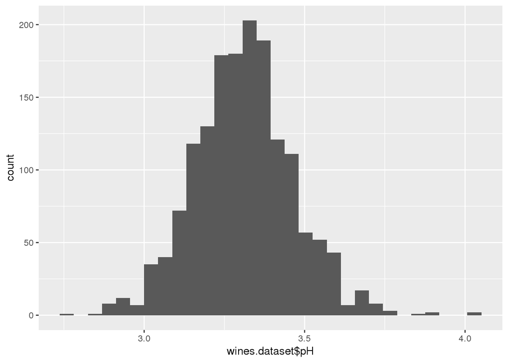

> OK, so it seems that pH is normaly distributed between our wines . lets check what is the distribution of quality -lets use factor to treat it as discrete. The wineQualityInfo.txt files inform us that pH describes “acidic” from very acidic (0) to very basic (14) and that most wines should be between 3 and 4

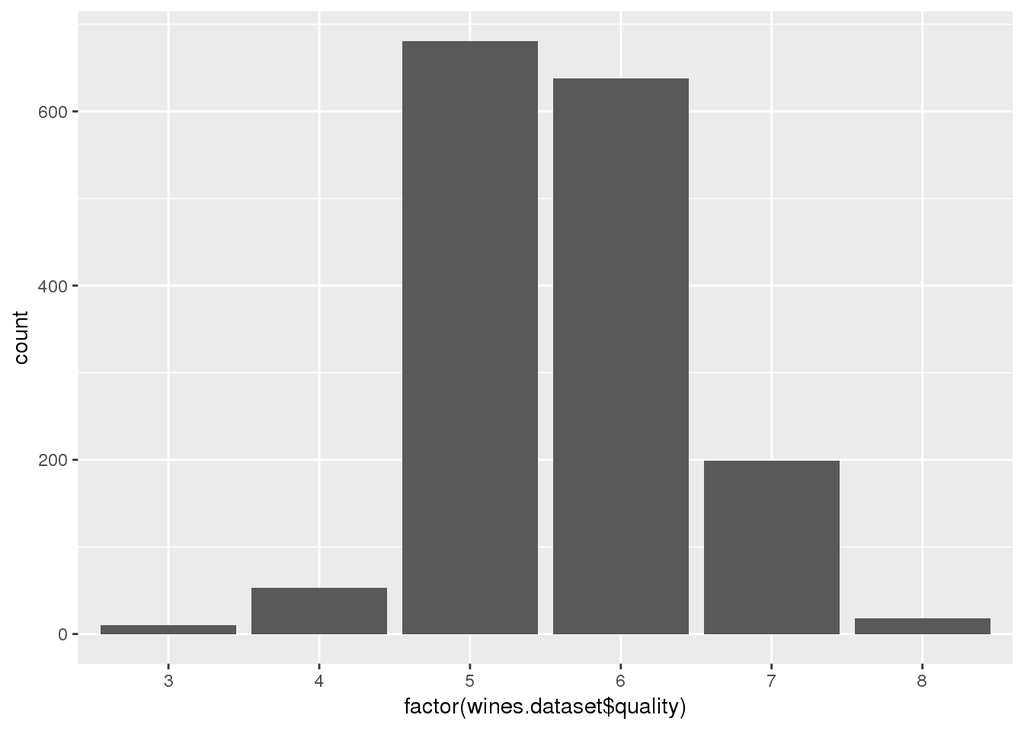

> OK , its clear too. Another almost normal distribution so it is time to find out what makes those high quality wines being apart from that huge number of medium quality wines in terms of chemical variables.

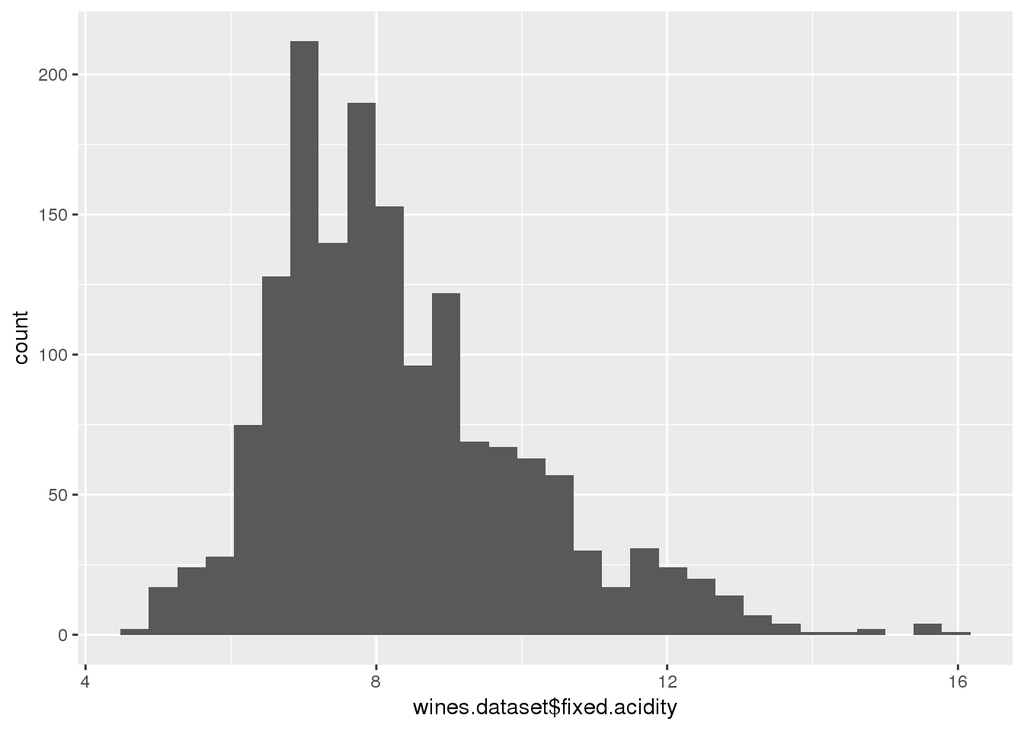

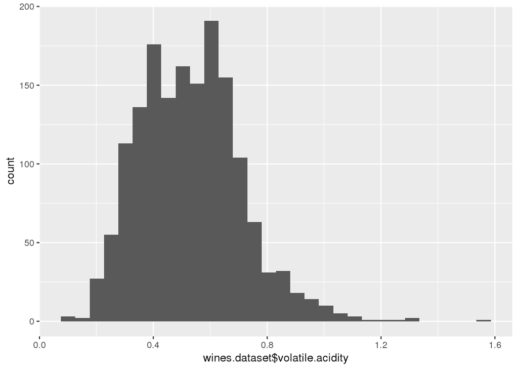

```
##    Min. 1st Qu.  Median    Mean 3rd Qu.    Max.
##    4.60    7.10    7.90    8.32    9.20   15.90
```

```
##    Min. 1st Qu.  Median    Mean 3rd Qu.    Max.
##  0.1200  0.3900  0.5200  0.5278  0.6400  1.5800
```

> Fixed and volatile acidity seems to be related and we can see that they have similar skewed distributions. It seems there are some outliers in both also since min and max values are far from 1st and 3rd qu. I am courious about the impact of acidity in quality (related with taste) and wonder if that group of wines with fixed acidity between 11 and 14 aprox share some special characteristics. The info file for our dataset has this information about acidicity : Most acids are nonvolatile (do not evaporate) -fixed acidity-, the rest is volatile, were high levels could lead to vinegar taste. So probably our outliers up the 3rd quartile (> 0.7) dont have good taste … Now check what about the distribution of dioxide variables

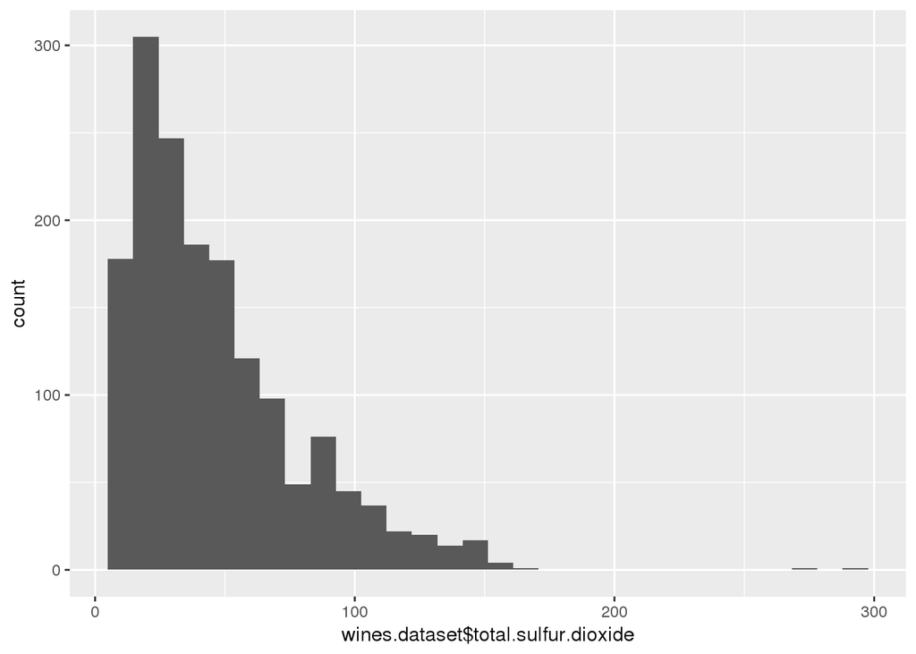

```
## [1] 546
```

> This is important : over 50 ppm of total sulfur dioxide (SO2) it starts to became evident in nose and taste and we have 546 observations with numbers greater that 50

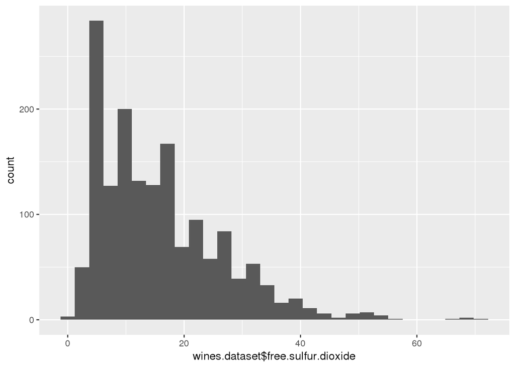

> Lets now check chlorides and sulfates to look for its distribution and understand is they also bring new questions

```
##    Min. 1st Qu.  Median    Mean 3rd Qu.    Max.
## 0.01200 0.07000 0.07900 0.08747 0.09000 0.61100
```

```
## [1] 41
```

> Aprox 2% of the observations have chlorides between 0.2 and 0.62 which is far above the 3rd quartile (0.09). Adjusting breaks and limits we can see that chlorides is normally distributed betwee 0.01 and 0.1.

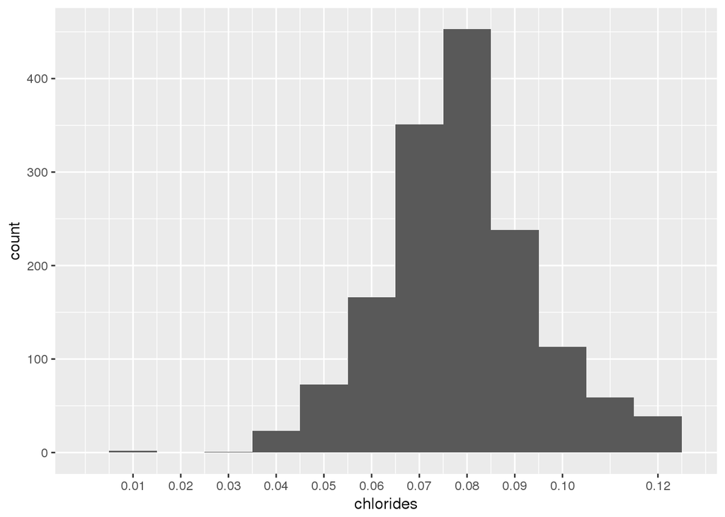

> Sulphates contribute to sulfur dioxide gas levels. As we already saw there are observations with high levels of sulfur dioxide gas so they should be related.

```
##    Min. 1st Qu.  Median    Mean 3rd Qu.    Max.
##  0.3300  0.5500  0.6200  0.6581  0.7300  2.0000
```

```
## [1] 228
```

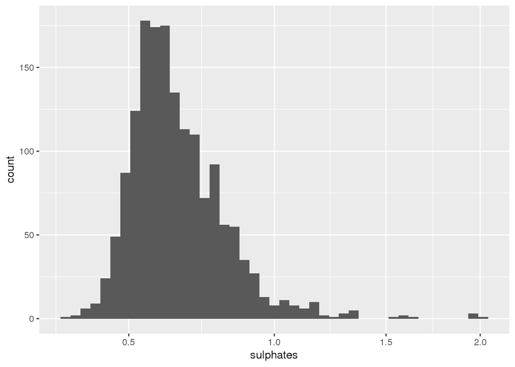

> In sulphates there are more than 200 obs (around 15%) above the 3rd quantile ….similar quantity of wines in highest quality categories (7 and 8) uhm, any correlation between sulphates and wine quality ?? . Should review that against the levels of sulfir dioxide and contribution to nose and taste… interesting.

> And last but non least, residual.sugar, alcohol and density

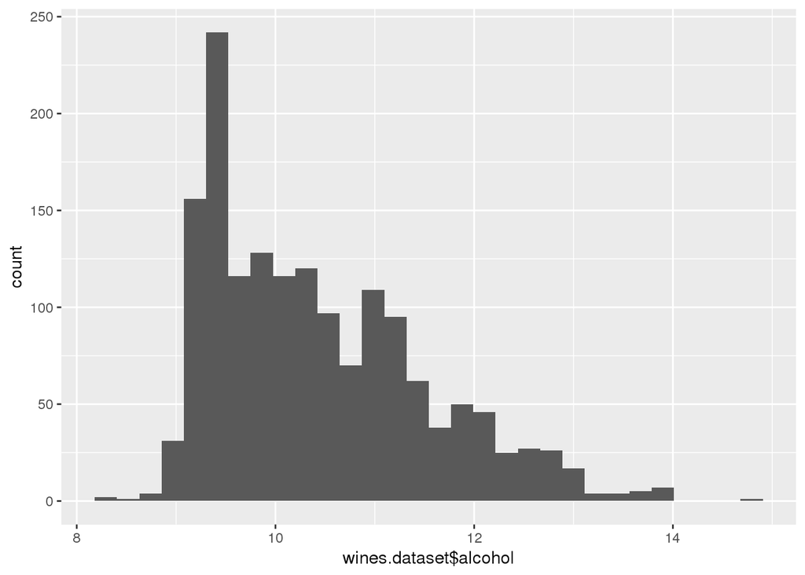

> Now , 3 variables that are related from the info we have : density, residual sugar and alcohol. I understand that density of water depend on % of alcohol and sugar ; the amount of sugar depend on when the fermentations stops, since the fermentation process means sugar to alcohol, residual sugar should decrease as fermentation is longer which produces more alcohol which affects the density of water. We already look at alcohol levels, lets plot residual sugar and density alongside

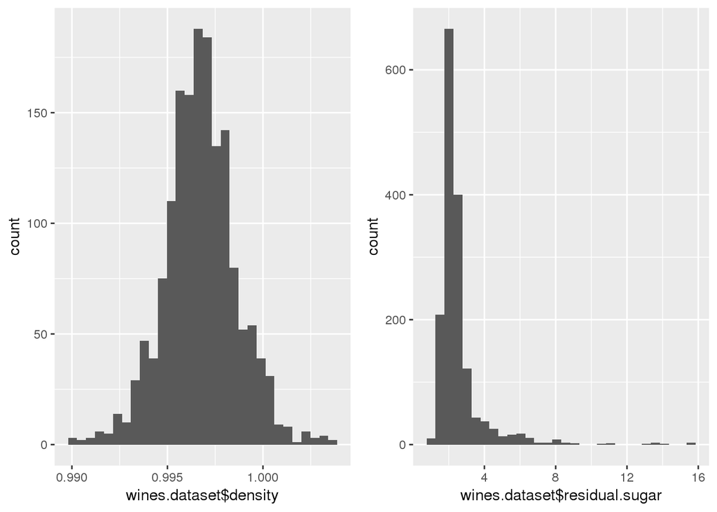

> ok, bins need to be adjusted and its time to get into the deal of putting more than two variables together. Before that, lets plot citric acid since impacts “freshness”

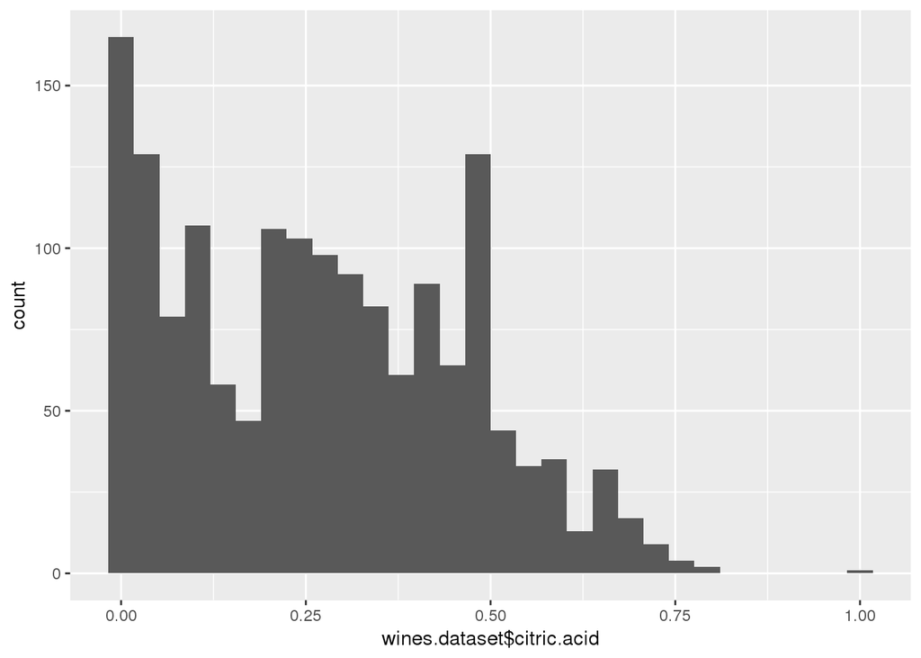

> Ops, at first sight it seems to me that we should take a look at the relation of this bi-modal like distribution with the other acid properties and the pH position of the wine

# Univariate Analysis

### What is the structure of your dataset?

> There are 1599 wines observed in this dataset with 12 variables which i would like to group in acid-related (fixed acidity, volatile acidity, citric acid and pH), SO2-related (free sulfur dioxide, total sulfur dioxide, and sulphates) , fermentation-related (alcohol, density and residual sugar) and quality and chlorides

> Other observations 1. pH is normally distributed and should be around 3 and 4 2. quality goes from 0 to 10 with most observations around 5 and 6 as expected 3. acidity , fixed and volatile, affects taste. Citric acid also drive the “freshness” of wines so there are lot of work to do around acidity. 4. Prescence of SO2 affects the taste and nose of wine and we have some observations that need to be analyzed in details like those more than 500 with 50 ppm total sulfur dioxide. 5. Alcohol, residual sugar and density needs to be analyzed together.

### What is/are the main feature(s) of interest in your dataset?

> From my point of view the main features of this dataset is wine quality. Now the challenge is to understand how the grouped features (SO2 related, acidity related and fermentation related) affects wine perceived quality.

### What other features in the dataset do you think will help support your investigation into your feature(s) of interest?

> As i mentioned above my plan is to find any correlations between SO2 vars, acidity vars and fermentation related vars between them and against quality

### Did you create any new variables from existing variables in the dataset?

> No at this time, just created variables from the dataset to analyze the distribution of alcohol

### Of the features you investigated, were there any unusual distributions? Did you perform any operations on the data to tidy, adjust, or change the form of the data? If so, why did you do this?

> There are outliers or exceptional cases in some distributions theh need to be investigated further. Residual sugar and dioxide distributions are skewed with outliers that require further analysis.

# Bivariate Plots Section

## SO2 related properties analysis against quality

> There are a group of SO2 related properties that affects taste and nose because of the prescense of SO2 in wine which is a sub-product of fermentation (free sulfur dioxide, total sulfur dioxide, and sulphates) First lets check our initial doubt with sulfures : there are any perceived relation between quality and wines with total.sulfur.dioxide greater than 50 ppm ?

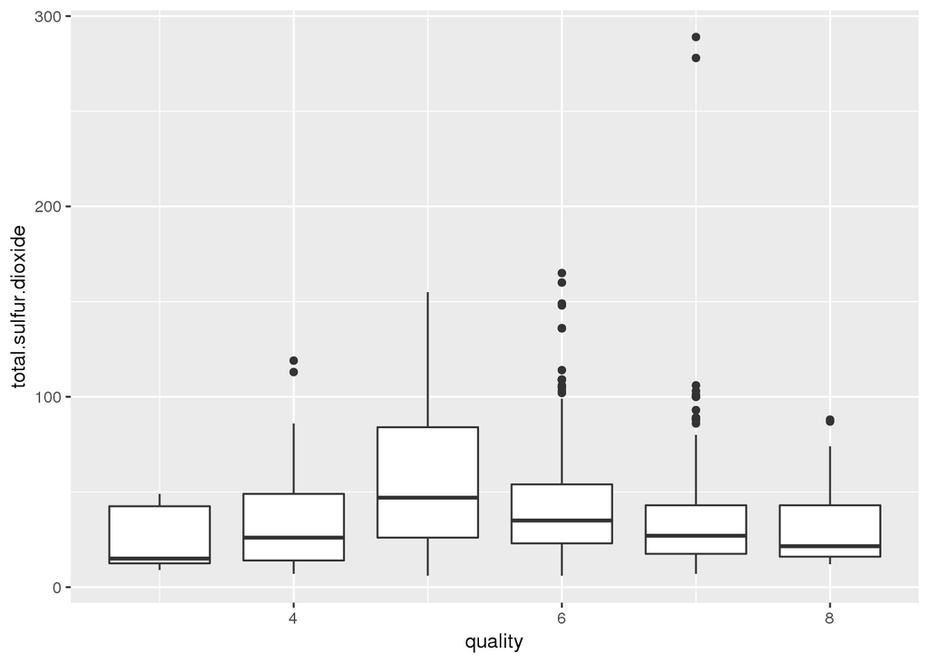

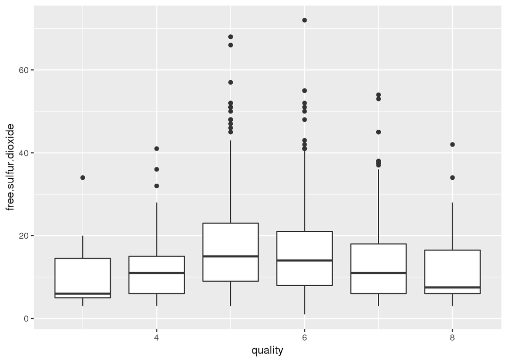

> So it seems to me that high sulfured observations are outliers as we can clearly see here and that there are no clear evidence that different wines qualities have specific sulfure composition. Lets move to alcohol and sugar.

```
##    Min. 1st Qu.  Median    Mean 3rd Qu.    Max.
##   0.900   1.900   2.200   2.539   2.600  15.500
```

## fermentation-related (alcohol, density and residual sugar)

> First lets clarify something : more alcohol means less residual sugar ?

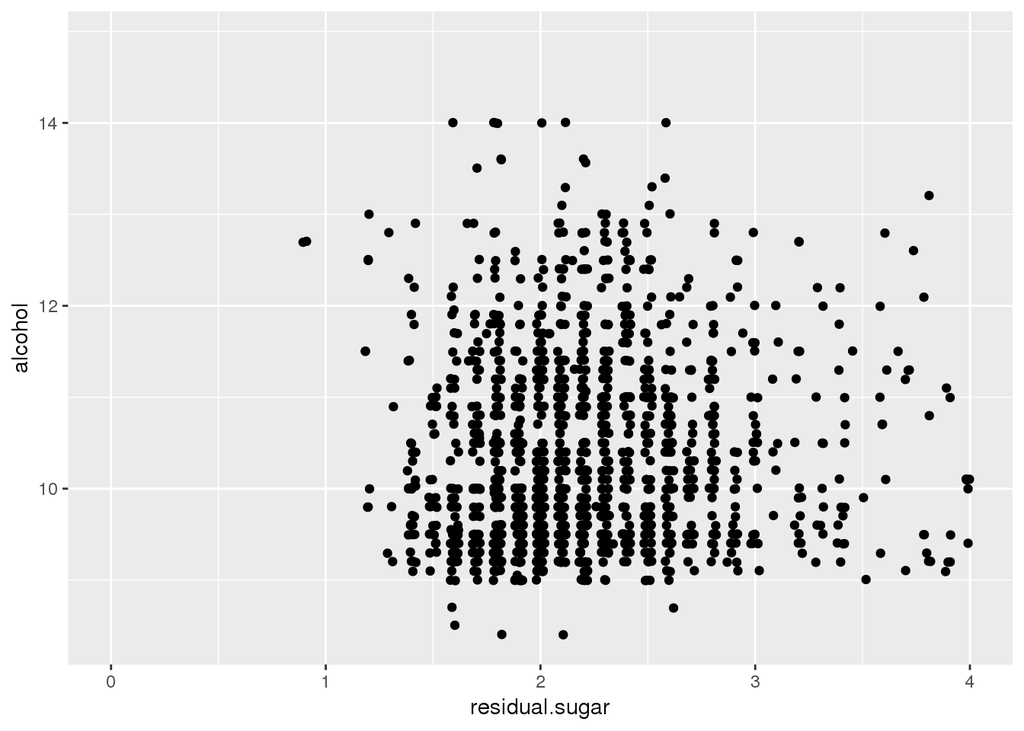

> residual sugar and queality ?

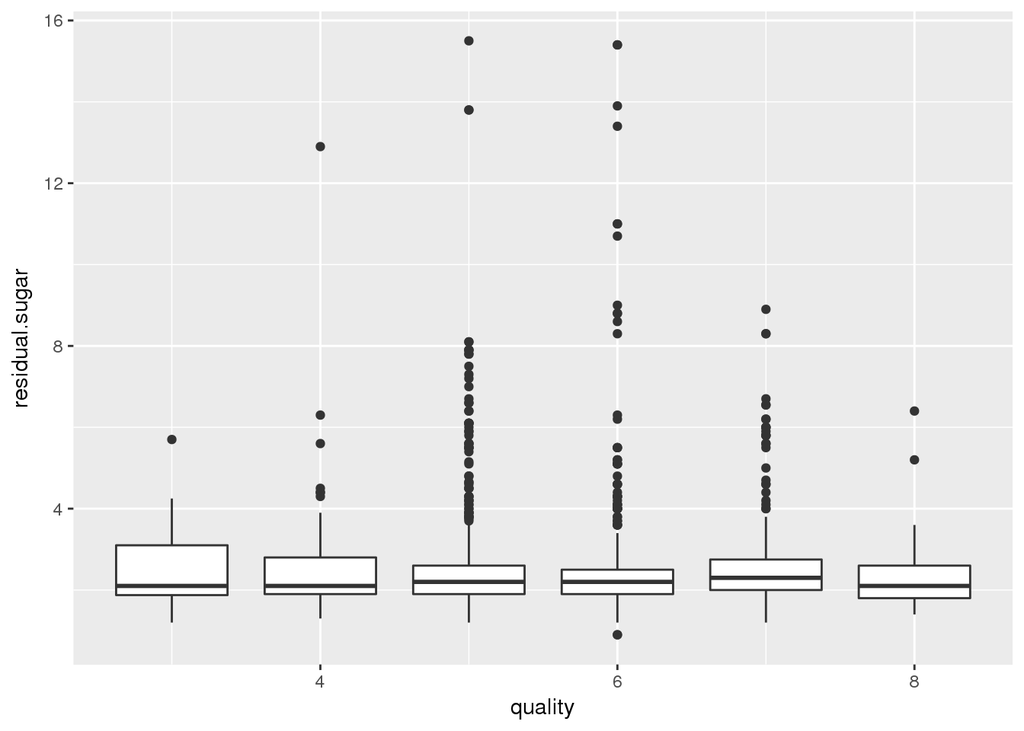

> (fixed acidity, volatile acidity, citric > acid and pH)

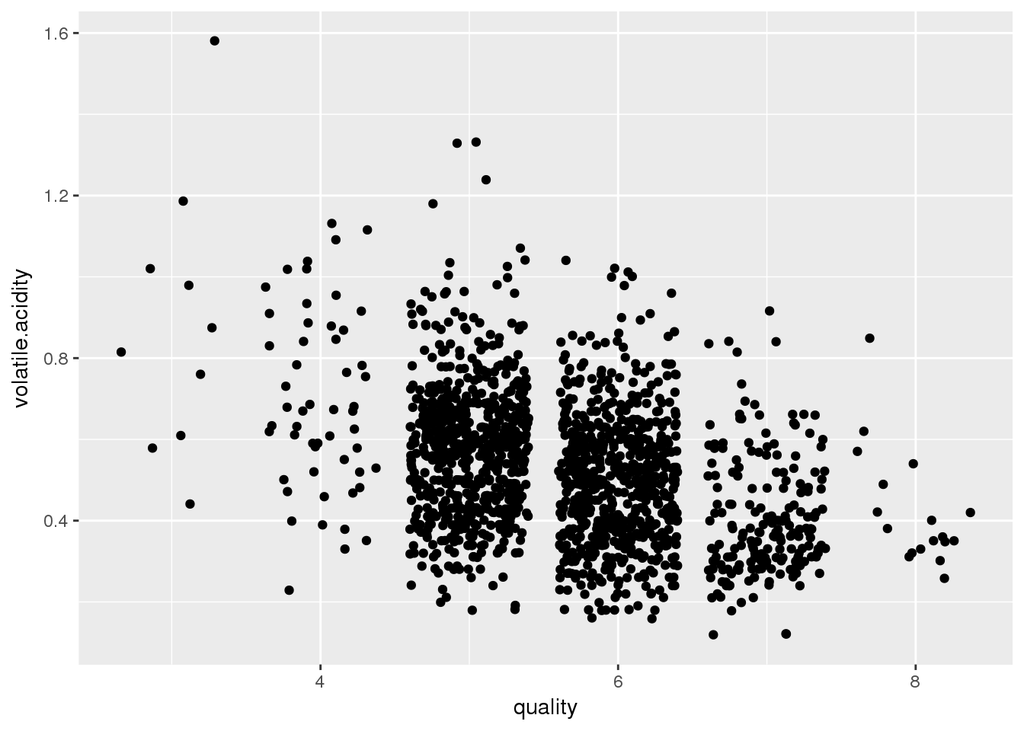

> seems to be something here lets check with boxplots

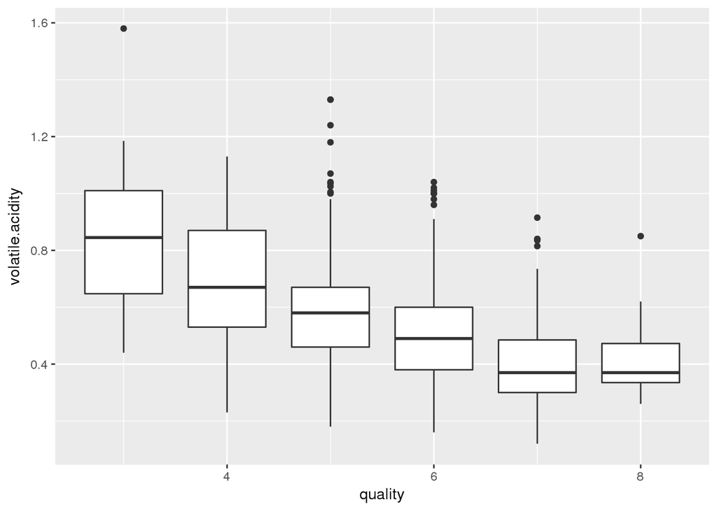

> OK !, now we have something : as soon as acidity gets reduced, quality of wine seems to improve. So what about pH

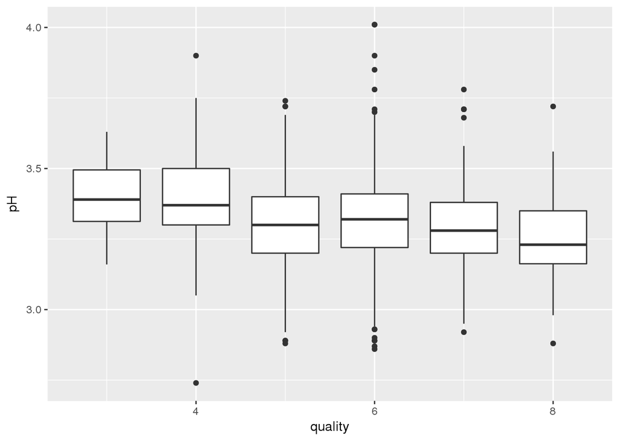

> and citric

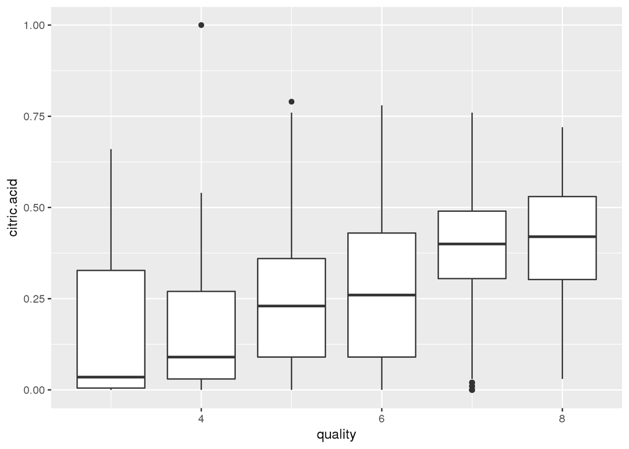

> OK, very nice, queality improves as citric acid prescence growth but volatile acidity is reduced . pH seems to be neutral in this case so i cant wait to move to multivariate analysis. Lets lastly check chlorides

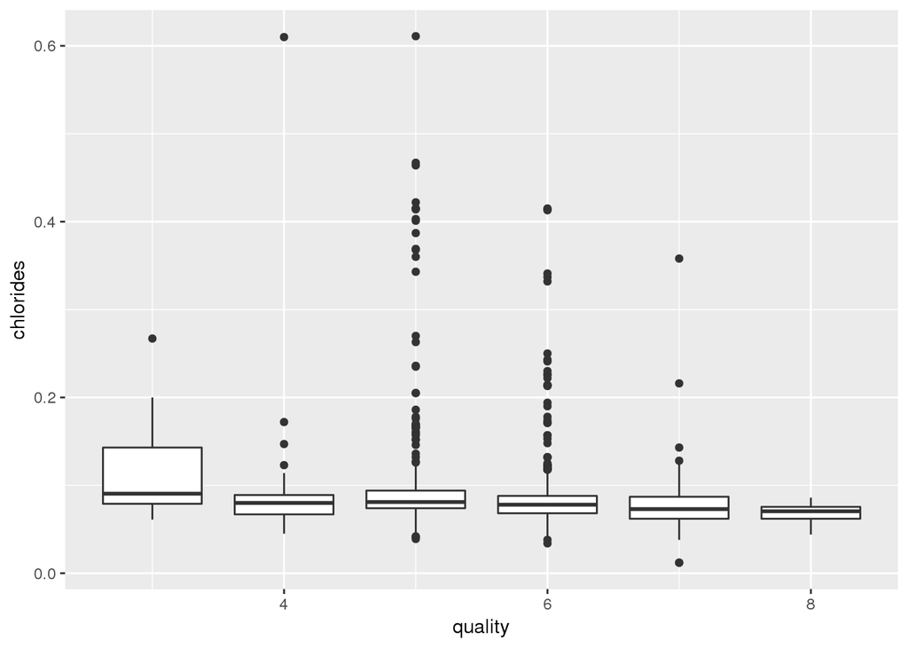

# Bivariate Analysis

### Talk about some of the relationships you observed in this part of the investigation. How did the feature(s) of interest vary with other features in the dataset?

> The review was based in the initial assessment were we found three related groups of variables to check against wine quality : SO2 related, fermentation related and acidity related.

> In the first and second group we could not found any sugestive evidence of correlation.

> The third group is the one we’ll explore further because quality seems to be altered with differences in acidity

### Did you observe any interesting relationships between the other features (not the main feature(s) of interest)?

> Away from the relationship between acidity (fixed and volatile , citric) with the quality of wine i am still interested in the comments in the dataset file about the impact of sulphures in nose given the amount of SO2. In the Bivariate observations it was not clear its impact on queality what i hope we could find a surprise on Multivariate explorations.

### What was the strongest relationship you found?

> Strongest relations as i already mentioned is the ones i found in the third group and mostly for the citric acid and volatile acidity against quality

# Multivariate Plots Section

> Lets classify our wines quality in low and mediaum (under 6) and high quality 7 and 8 so we can clarify the netx plots with more clear definitions.

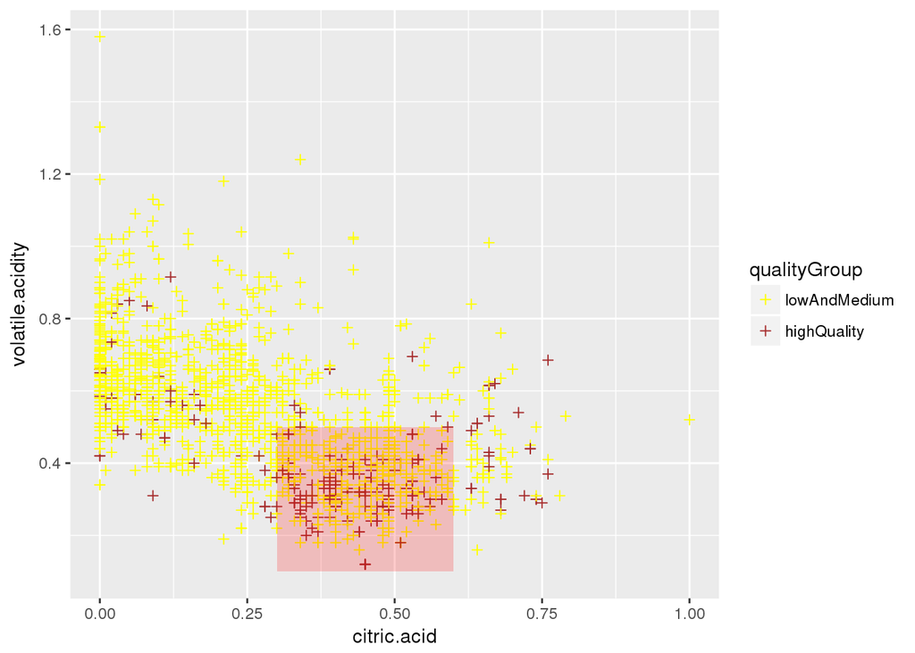

> Wow, as expected this plot shows the combined incidence of volatile acidity and citric acidity on wine quality. As the rectangle remarks, there is an area where high quality wines gets grouped which could be categorized as a low volatile acidity and medium to high citric acid area.

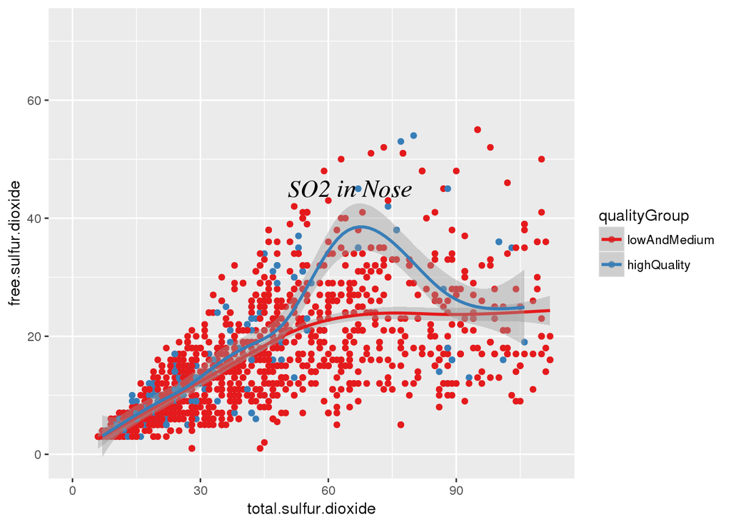

> OK, so this is the answer to the sulphure mistery ? Probably. It shows that there is a region , over 50ppm of total sulfur dioxide, where high quality wines separate from low and Medium (it is marked with “SO2 in Nose”)

# Multivariate Analysis

### Talk about some of the relationships you observed in this part of the investigation. Were there features that strengthened each other in terms of looking at your feature(s) of interest?

> I could plot the relationships that i was looking for after reading the txt file and the plotting of bivariate plots: 1. The relationship between volatile acidity and citric acid over the quality of wines. 2. The impact of sulfur dioxide , for a specific range of values, in the difference between low and medium and high quality wines included with the dataset and after

### Were there any interesting or surprising interactions between features?

> Yes. Actually it seems that sulfur is something that needs to be carefully controlled because too much is bad for wine quality and too low means no differentiation with low and medium wines.

# Final Plots and Summary

### Plot One

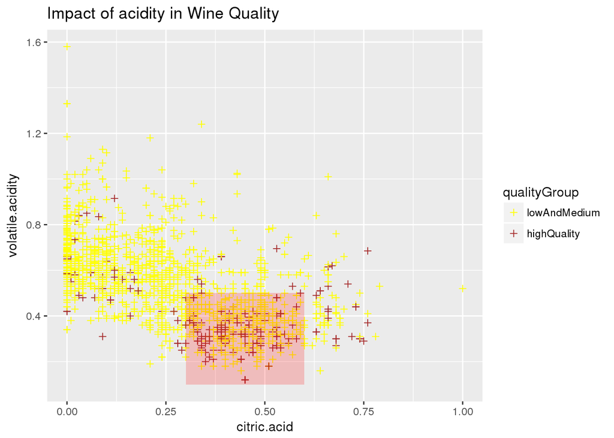

### Plot Two

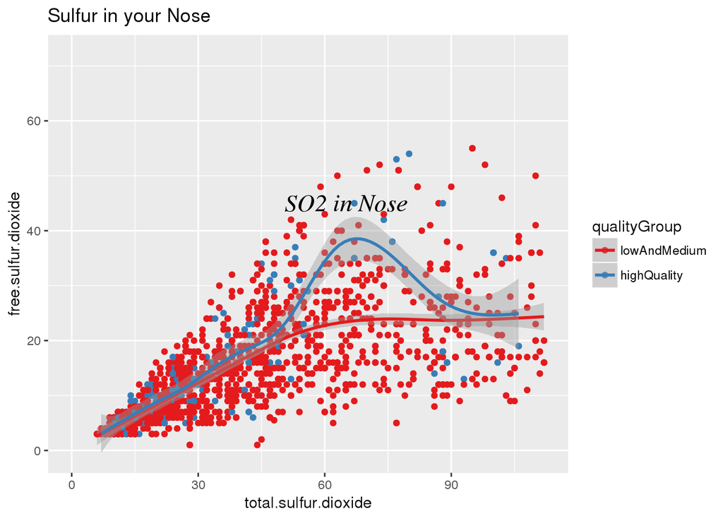

### Description Two

> “Never in excess” …and we are not talking in this case about the alcohol level, we talk about free sulfur dioxide. There is a range of values were the prescense of free sulfure dioxide and the “bubbles” sensation goes hand in hand with wine quality ….but…if it is in excess then wine will be converted back to a normal wine.

### Plot Three

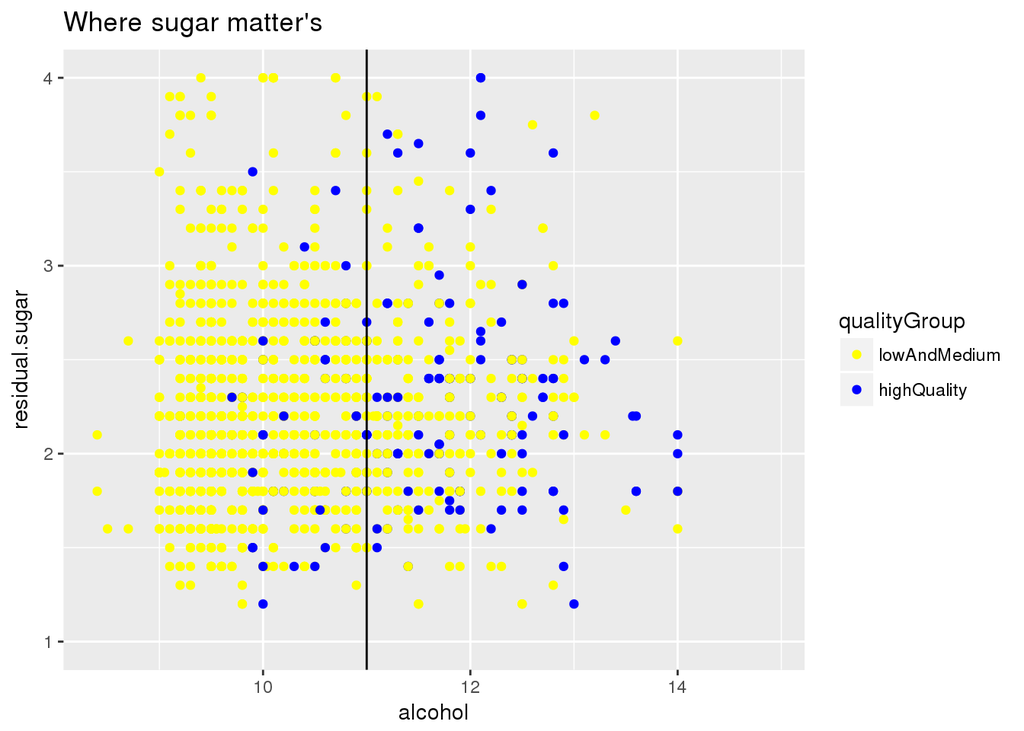

# Reflection

> OK, reach the final of the exploration. It is a great dataset to learn and it is a very interesting topic mostly for countries like argentina where wine is so pervasive and most of argentinians like to have educated opinions on wine quality. I would like to have included in the dataset at least 1 additional variable: it would be nice to have the production year of the wine. The reasson is because it it perceived that older wines are better but not old wines got better the same. It suprised me the impact of acidity factors in wine quality. It would be nice to explore if there are any relation between acidity and different wineyards locations (that could be another variable to include in the dataset). Basically we could say that quality of wine is impacted by citric acid (direct) and volatile acidity (inverse). Additionaly , and closelly related with the fermentation process, as sugar get consumed to produce alcohol SO2 gets liberated and some gain prescense in the wine itself. A mid term prescense of SO2 with moderate to high alcohol graduation seems to inpact the quality of wine too. I got only minor problems during the analisis and they were not directly related with the dataset. It was in the bivariate section where sometimes it was difficult for me to express or review the relation with clarity using scatter plots and that’s the reasson why i choosed to move the plots to boxplots. I guess i needed to review in more detail the options to adjust scatter plots and better deal with different time of variables on them.